[output not shown]

# Introduction

Topic models are probabilistic latent variable models of documents that exploit the correlations among the words and latent semantic themes” (Blei and Lafferty, 2007). The name “topics” signifies the hidden, to be estimated, variable relations (=distributions) that link words in a vocabulary and their occurrence in documents. A document is seen as a mixture of topics. This intuitive explanation of how documents can be generated is modeled as a stochastic process which is then “reversed”" (Blei and Lafferty, 2009) by machine learning techniques that return estimates of the latent variables. With these estimates it is possible to perform information retrieval or text mining tasks on a document corpus.

# Loading required libraries

In this study we will utilize R tm R package for querying and textmining of the NIPS Papers 2015

```r
library(tm) ## texmining
library(lda) ## the actual LDA model
library(LDAvis) # visualization library for LDA

library(parallel) # multi-core paralellization

library(data.table) # fread
library(Rmpfr) # harmonic mean maximization
library(ggplot2) # pretty plotting lib
library(reshape2) # reformatting lib for ggplot2

library(tsne) # low dimensional embedding
library(caret) # ml model wrapper lib, but only used for data transformation here

library(rbokeh) # pretty (interactive) plotting

load("ldaModels_NIPS2015_k2to25_alpha001to12.rda")
load("vocab.rda")
load("termTable.rda")
load("documents.rda")
```

# Helper Functions

```r
#' Copy arguments into env and re-bind any function's lexical scope to bindTargetEnv .
#'
#' See http://winvector.github.io/Parallel/PExample.html for example use.
#'
#'
#' Used to send data along with a function in situations such as parallel execution
#' (when the global environment would not be available).  Typically called within
#' a function that constructs the worker function to pass to the parallel processes
#' (so we have a nice lexical closure to work with).
#'
#' @param bindTargetEnv environment to bind to
#' @param objNames additional names to lookup in parent environment and bind
#' @param names of functions to NOT rebind the lexical environments of
bindToEnv <- function(bindTargetEnv=parent.frame(), objNames, doNotRebind=c()) {
  # Bind the values into environment
  # and switch any functions to this environment!
  for(var in objNames) {
    val <- get(var, envir=parent.frame())
    if(is.function(val) && (!(var %in% doNotRebind))) {
      # replace function's lexical environment with our target (DANGEROUS)
      environment(val) <- bindTargetEnv
    }
    # assign object to target environment, only after any possible alteration
    assign(var, val, envir=bindTargetEnv)
  }
}

startCluster <- function(cores=detectCores()) {
  cluster <- makeCluster(cores)
  return(cluster)
}

shutDownCluster <- function(cluster) {
  if(!is.null(cluster)) {
    stopCluster(cluster)
    cluster <- c()
  }
}
```

# Read the NIPS 2015 Corpus

First we will read all the nips papers in a data frame. We will use the abstracts for the training of our LDA

```r
papers = fread("~/Datasets/kaggle/NIPS2015_papers/Papers.csv")
docs = papers$Abstract
```

# Preprocessing

```r
stop_words <- stopwords("SMART")
docs <- gsub("[[:punct:]]", " ", docs)  # replace punctuation with space
docs <- gsub("[[:cntrl:]]", " ", docs)  # replace control characters with space
docs <- gsub("^[[:space:]]+", "", docs) # remove whitespace at beginning of documents
docs <- gsub("[[:space:]]+$", "", docs) # remove whitespace at end of documents
docs <- tolower(docs)  # force to lowercase

# tokenize on space and output as a list:
doc.list <- strsplit(docs, "[[:space:]]+")

# Remove all words with less than 4 characters
doc.list <- lapply(doc.list, function(x) x[sapply(x, nchar)>3])

# compute the table of terms:
term.table <- table(unlist(doc.list))
term.table <- sort(term.table, decreasing = TRUE)

# remove terms that are stop words or occur fewer than 5 times:
del <- names(term.table) %in% stop_words | term.table < 5
term.table <- term.table[!del]
vocab <- names(term.table)

save(vocab, file="vocab.rda")
save(term.table, file="termTable.rda")
```

Next we reformated the documents into the format required by the lda package.

```r
get.terms <- function(x) {
  index <- match(x, vocab)
  index <- index[!is.na(index)]
  rbind(as.integer(index - 1), as.integer(rep(1, length(index))))
}
documents <- lapply(doc.list, get.terms)

save(documents, file="documents.rda")
```

Before we start training our LDA, we first will calculate some statistics related to the data set:

```r
D <- length(documents)  # number of documents
W <- length(vocab)  # number of terms in the vocab
doc.length <- sapply(documents, function(x) sum(x[2, ]))  # number of tokens per document
N <- sum(doc.length)  # total number of tokens in the data
term.frequency <- as.integer(term.table)  # frequencies of terms in the corpus
```

```r
df <- data.frame("Number of Documents"=D,
                 "Number of Terms in Vocabulary"=W,
                 "Total Number of Tokens in Corpus"=N)

knitr::kable(df, digits = 0, caption = "Document Statistics")
```

Document Statistics

| Number.of.Documents | Number.of.Terms.in.Vocabulary | Total.Number.of.Tokens.in.Corpus |
| --- | --- | --- |
| 403 | 1384 | 27014 |

# LDA Parameters

For the symmetric dirichlet distribution, a high alpha-value means that each document is likely to contain a mixture of most of the topics, and not any single topic specifically. A low alpha value puts less such constraints on documents and means that it is more likely that a document may contain mixture of just a few, or even only one, of the topics. Likewise, a high beta-value means that each topic is likely to contain a mixture of most of the words, and not any word specifically, while a low value means that a topic may contain a mixture of just a few of the words.

If, on the other hand, the distribution is asymmetric, a high alpha-value means that a specific topic distribution (depending on the base measure) is more likely for each document. Similarly, high beta-values means each topic is more likely to contain a specific word mix defined by the base measure.

In practice, a high alpha-value will lead to documents being more similar in terms of what topics they contain. A high beta-value will similarly lead to topics being more similar in terms of what words they contain. (source: http://stats.stackexchange.com/questions/37405/natural-interpretation-for-lda-hyperparameters)

```r
G <- 1000 ## number of iterations
# alpha   ## Papers are very specific such that a low alpha is more probable.
# eta     ## The scalar value of the Dirichlet hyperparamater for topic multinomials.
k = seq(2, 25, by=1) ## The number of topics a document contains.

## We will define parameter sets for 2400 LDA models,
## which can be trained in about 1 hour using 8 cpu threads‚
params <- expand.grid(G=G,
                      k=k,
                      alpha=seq(0.01, 100, length.out=10),
                      eta=seq(0.01, 100, length.out=10))
params <- setNames(split(params, seq(nrow(params))), rownames(params))
```

# Model Tuning

With the parameters defined above we can now go on and train our set of models. For parallel computing we will define our worker function, which will bind all variables needed during training to the global environment, such that they are available for each core. TODO: Proper explaination on http://www.win-vector.com/blog/2016/01/parallel-computing-in-r/

# Multi CPU Computation

```r
set.seed(357)

# worker <- function() {
#   bindToEnv(objNames=c("documents", "vocab", "G", "alpha", "eta"))
#   function(k) {
#     lda::lda.collapsed.gibbs.sampler(documents = documents, K = k, vocab = vocab,
#                                      num.iterations = G, alpha = alpha,
#                                      eta = eta, initial = NULL, burnin = 0,
#                                      compute.log.likelihood = TRUE)
#   }
# }

worker <- function() {
  bindToEnv(objNames=c("documents", "vocab"))
  function(params) {
    k <- params$k
    G <- params$G
    alpha <- params$alpha
    eta <- params$eta
    lda::lda.collapsed.gibbs.sampler(documents = documents, K = k, vocab = vocab,
                                     num.iterations = G, alpha = alpha,
                                     eta = eta, initial = NULL, burnin = 0,
                                     compute.log.likelihood = TRUE)
  }
}

t1 <- Sys.time()
cluster <- startCluster()
# models <- parLapply(cluster, ntopics, worker())
models <- parLapply(cluster, params, worker())
shutDownCluster(cluster)
t2 <- Sys.time()
t2 - t1

save(models, file="ldaModels_NIPS2015.rda")
```

# Single CPU Computation

```r
t1 <- Sys.time()
models = lapply(ntopics, lda::lda.collapsed.gibbs.sampler(documents = documents, K = k, vocab = vocab,
                                                          num.iterations = params$G, alpha = params$alpha,
                                                          eta = params$eta, initial = NULL, burnin = 0,
                                                          compute.log.likelihood = TRUE))
t2 <- Sys.time()
t2 - t1
```

# Convergence

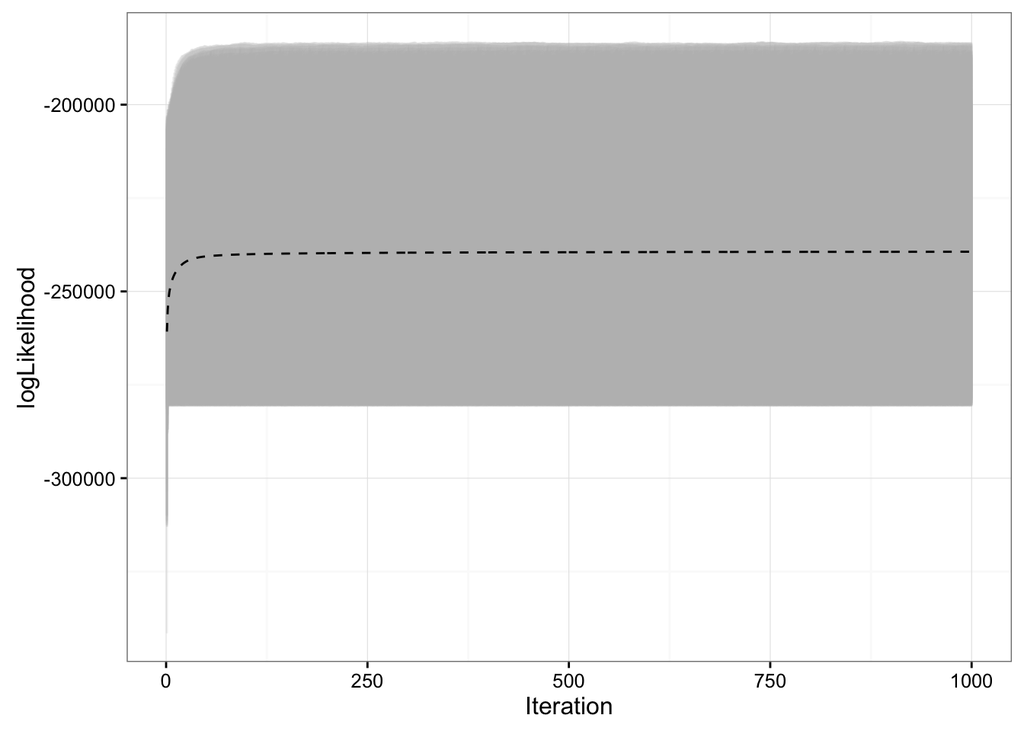

# Model Selection

We will select our model based on harmonic mean maximization. TODO: Check http://epub.wu.ac.at/3558/1/main.pdf for proper explanation and comparison to other performance values. TODO: Fix harmonic mean calculation.

```r
harmonicMean = function(logLikelihoods, precision=2000L) {
  llMed = median(logLikelihoods)
  as.double(llMed - log(mean(exp(-mpfr(logLikelihoods,
                                       prec = precision) + llMed))))
}

params <- expand.grid(G=G,
                      k=k,
                      alpha=seq(0.01, 100, length.out=10),
                      eta=seq(0.01, 100, length.out=10))

## TODO: Check whether the matrix is filled in the right order
## returns a grid of harmonic mean log likelihoods
## for a fixed number of topics k and a fixed number of iterations
## gradient lines are plotted against the LDA hyperparameters alpha and eta
paramMatrix <- function(k, params, models) {
  topic.params <- params[which(params$k==k),]
  indexes <- as.numeric(rownames(topic.params))
  alpha <- unique(topic.params$alpha)
  eta <- unique(topic.params$eta)
  selectedModels <- models[indexes]
  logLiks = lapply(selectedModels, function(m)  m$log.likelihoods[1, ])
  harmMeanLogLiks <- sapply(logLiks, function(h) harmonicMean(h))
  m <- matrix(harmMeanLogLiks, nrow=length(alpha), ncol=length(eta))
  rownames(m) <- alpha
  colnames(m) <- eta
  return(m)
}

## Test whether matrix has been filled correctly and axis labels are correct
# topic.params <- params[which(params$k==3),]
# print(topic.params)
# indexes <- as.numeric(rownames(topic.params))
# alpha <- unique(topic.params$alpha)
# eta <- unique(topic.params$eta)
# selectedModels <- models[indexes]
# logLiks = lapply(selectedModels, function(m)  m$log.likelihoods[1, ])
# harmMeanLogLiks <- sapply(logLiks, function(h) harmonicMean(h))
#
# m <- melt(m_3)
# colnames(m) <- c("alpha", "eta", "HarmonicMeanlogLikelihood" )
#
# ggplot(data=m, aes(x=alpha, y=eta, z=HarmonicMeanlogLikelihood)) +
#   stat_contour(bins=20, aes(colour = ..level..)) +
#   theme_bw()
#
# harmonicMean(models[[137]]$log.likelihoods[1, ]) ## alpha=55.56, eta=11.12 --> -218668.9
# harmonicMean(models[[47]]$log.likelihoods[1, ])  ## alpha=55.56, eta=0.01 --> should be smaller than -218668.9
# harmonicMean(models[[173]]$log.likelihoods[1, ])  ## alpha=100.00, eta=11.12 --> should be close to -218668.9

## contour matrices for each k over alpha and eta hyper-parameters
contourMatrices <- lapply(unique(params$k), paramMatrix, params, models)
## vector of argmax(likelihood) indices over all alphas of each contour matrix
opt_alphas <- sapply(contourMatrices, function(m) which(rowSums(m)==max(rowSums(m))))
## vector of argmax(likelihood) indices over all etas of each contour matrix
opt_etas   <- sapply(contourMatrices, function(m) which(colSums(m)==max(colSums(m))))
logLiks    <- sapply(contourMatrices, function(m) max(apply(m, 1, max)))
## Combine everything in a data frame including the optimal parameters over all LDAs with
## a fixed k and number of iterations G
opt_params <- data.frame(k=unique(params$k),
                         alpha=names(opt_alphas),
                         eta=names(opt_etas),
                         logLikelihood=logLiks)

knitr::kable(opt_params, caption = "Optimal LDA hyper-parameter settings over all k and a fixed number of iterations G")
```

Optimal LDA hyper-parameter settings over all k and a fixed number of iterations G

| k | alpha | eta | logLikelihood |
| --- | --- | --- | --- |
| 2 | 100 | 11.12 | -203099.2 |
| 3 | 88.89 | 11.12 | -214776.3 |
| 4 | 88.89 | 11.12 | -223146.3 |
| 5 | 100 | 11.12 | -229658.0 |
| 6 | 100 | 11.12 | -234975.3 |
| 7 | 100 | 11.12 | -239560.9 |
| 8 | 100 | 11.12 | -243511.0 |
| 9 | 100 | 11.12 | -246878.2 |
| 10 | 88.89 | 11.12 | -250025.3 |
| 11 | 100 | 11.12 | -252904.7 |
| 12 | 88.89 | 11.12 | -255480.6 |
| 13 | 100 | 11.12 | -257848.9 |
| 14 | 100 | 11.12 | -260064.5 |
| 15 | 100 | 11.12 | -262161.9 |
| 16 | 88.89 | 11.12 | -264012.9 |
| 17 | 88.89 | 11.12 | -265839.5 |
| 18 | 100 | 11.12 | -267477.5 |
| 19 | 88.89 | 11.12 | -269183.8 |
| 20 | 100 | 11.12 | -270656.3 |
| 21 | 88.89 | 11.12 | -272154.9 |
| 22 | 100 | 11.12 | -273470.9 |
| 23 | 100 | 11.12 | -274822.2 |
| 24 | 100 | 11.12 | -276130.2 |
| 25 | 100 | 11.12 | -277326.0 |

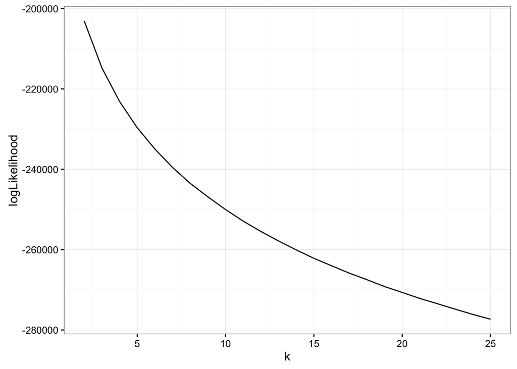

```r
ggplot(data=opt_params, aes(x=k, y=logLikelihood)) +
  geom_line() +
  theme_bw()
```

```r
## This will select a model with 2 topics. This doesn't make sense, given some exploration beforehand
## Especially with regard to the t-SNE dimensionality reduction which identifies about 8-9 clusters in the corpus.
i <- which(opt_params$logLikelihood==max(opt_params$logLikelihood))
i=20
opt_k <- as.numeric(as.character(opt_params[i, ]$k))
opt_alpha <- as.numeric(as.character(opt_params[i, ]$alpha))
opt_eta <- as.numeric(as.character(opt_params[i, ]$eta))
opt_model_index <- as.numeric(rownames(subset(params, (k==opt_k &
                                                       alpha==opt_alpha &
                                                       eta==opt_eta))))
model <- models[[opt_model_index]]
```

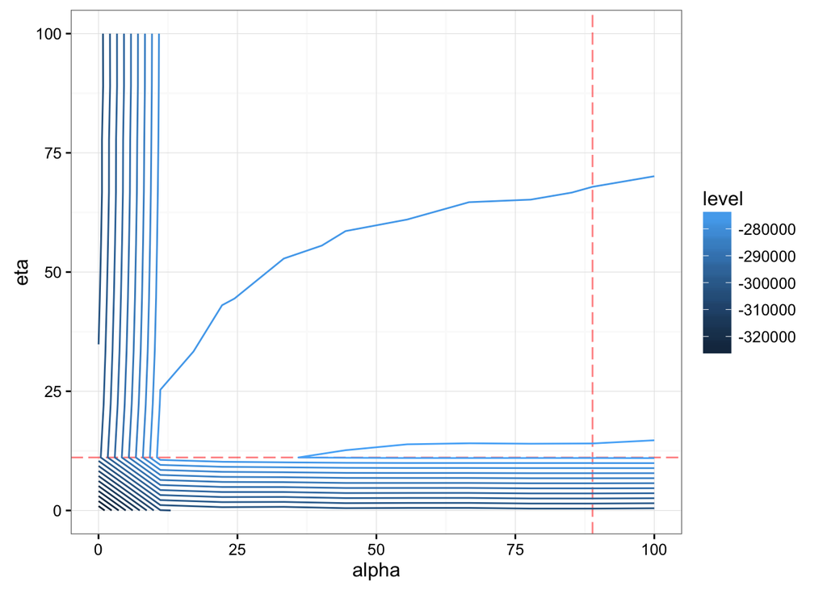

The optimal model is described by the following parameters: alpha=88.89 and eta=11.12.